# Epilepsy Prediction with ML Models

Yixuan Yang

# Set Up

```r
rm(list = ls())
set.seed(2024)
library(tidyverse)
library(tidymodels)
library(phyloseq)
library(here)
library(skimr)
library(patchwork)
theme_set(theme_bw())
# load data
ps.rare <- readRDS(here('data','following_study','ps_rarefied.rds')) %>%
  filter_taxa(function(x) sum(x > 0)/length(x) > 0.1, prune = TRUE)
```

# Start

In this section, we want to try to use machine learning models to predict the epilepsy status of the dogs based on their microbiome data. Here we are using the rarefied data with each taxa has at least 10% prevalence in our data.

For each model, we tried to use:

1. microbial data at phylum level
2. microbial data at ASV level
3. dimension reduced microbial data by `PCoA` method

We used 70% data to train models and 30% data for testing. All models are trained and tested using 10-fold cross-validation repeated 10 times. The best model is selected based on the accuracy metric. As model performance varies, each model is trained and tested 30 times, and the mean and standard deviation of the accuracy are reported.

# Data Preprocess

**ASV level**

```r
ps.rare.asv <- ps.rare
sam <- data.frame(sample_data(ps.rare.asv)) %>%
    dplyr::select(Epileptic.or.Control, Household)
otu <- data.frame(otu_table(ps.rare.asv))
# combine data to a data frame
ps.data <- bind_cols(sam, otu)
data_split <- group_initial_split(ps.data, group = 'Household', prop = 0.7)
Recipe <- recipe(Epileptic.or.Control ~ ., data = training(data_split)) %>%
        update_role(Household, new_role = 'group variable')
Recipe
```

```
## ── Recipe ──────────────────────────────────────────────────────────────────────
```

```
## ── Inputs
```

```
## Number of variables by role
```

```
## outcome:          1
## predictor:      322
## group variable:   1
```

**Phylum level**

```r
ps.rare.phylum <- ps.rare  %>%
    tax_glom(taxrank = 'Phylum')
sam <- data.frame(sample_data(ps.rare.phylum)) %>%
    dplyr::select(Epileptic.or.Control, Household)
otu <- data.frame(otu_table(ps.rare.phylum))
# combine data to a data frame
ps.data <- bind_cols(sam, otu)
data_split <- group_initial_split(ps.data, group = 'Household', prop = 0.7)
Recipe <- recipe(Epileptic.or.Control ~ ., data = training(data_split)) %>%
        update_role(Household, new_role = 'group variable')
Recipe
```

```
## ── Recipe ──────────────────────────────────────────────────────────────────────
```

```
## ── Inputs
```

```
## Number of variables by role
```

```
## outcome:        1
## predictor:      7
## group variable: 1
```

**PCoA**

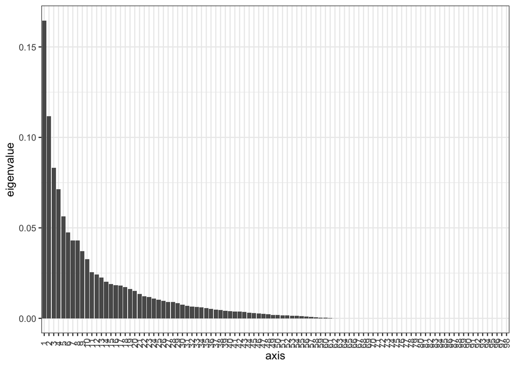

```r
pcoa <- ps.rare %>%
  ordinate(method = 'PCoA', distance = 'bray')
plot_scree(pcoa)
```

```r
n.vecter <- 30
pcoa$values$Cum_corr_eig[n.vecter]
```

```
## [1] 0.6925963
```

# Model Training and Testing

All model training script are stored in `code/machine-learning-models` folder.

All model performance results are stored in `data/following_study/ml-performance` folder.

# Results

```r
model.performance <- list.files(here('data', 'following_study', 'ml-performance'),
                                pattern = '.csv',
                                full.names = TRUE) %>% map_dfr(read.csv)
```

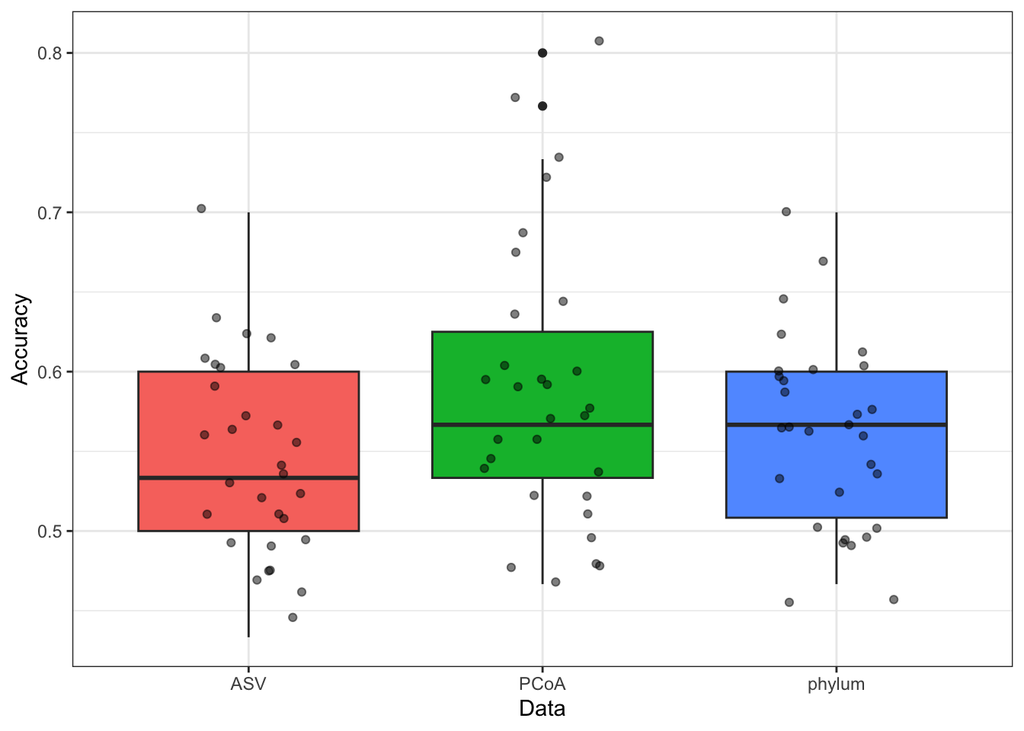

```r
model.performance %>%
  ggplot(aes(x = data, y = accuracy, fill = data)) +
  geom_boxplot() +
  geom_jitter(width = 0.2, alpha = 0.5) +
  labs(x = 'Data', y = 'Accuracy') +
  theme(legend.position = 'none')
```

```r
ggsave(here('figures', 'Figure6.png'))
ggsave(here('figures', 'Figure6.pdf'))
model.performance.summary <- model.performance %>%
  group_by(method, data) %>%
  summarise(mean = mean(accuracy), sd = sd(accuracy))
model.performance.summary
```

```
## # A tibble: 3 × 4
## # Groups:   method [1]
##   method        data    mean     sd
##   <chr>         <chr>  <dbl>  <dbl>
## 1 random forest ASV    0.547 0.0629
## 2 random forest PCoA   0.588 0.0899
## 3 random forest phylum 0.562 0.0572
```

```r
anova(lm(accuracy ~ data, data = model.performance))
```

```
## Analysis of Variance Table
##
## Response: accuracy
##           Df  Sum Sq   Mean Sq F value Pr(>F)
## data       2 0.02585 0.0129259  2.5326 0.0853 .
## Residuals 87 0.44404 0.0051039
## ---
## Signif. codes:  0 '***' 0.001 '**' 0.01 '*' 0.05 '.' 0.1 ' ' 1
```